# 4.3. Feature engineering

```r
install.packages('tidymodels')
```

```
Error in install.packages : Updating loaded packages
```

```r
library(lubridate)
library(recipes)
library(caret)
library(reshape2)
library(tidymodels)
```

## Age.Group

Od atributa Age kreiramo novi atribut Age.Group

```r
data$Age.Group <- cut(
  data$Age,
  breaks = c(-Inf, 25, 35, 50, 65, Inf),
  labels = c("≤25", "26–35", "36–50", "51–65", "65+"),
  right = TRUE,
  ordered_result = TRUE
)
```

Graficki prikaz podataka

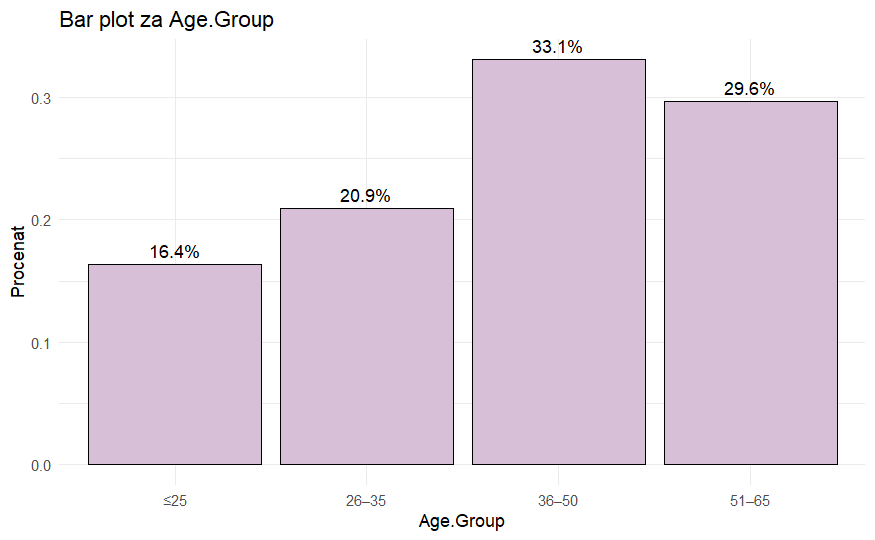

```r
ggplot(data, aes(x = Age.Group, y = ..prop.., group = 1)) +
  geom_bar(fill = "thistle", color = "black") +
  geom_text(aes(label = scales::percent(..prop..)), stat = "count", vjust = -0.5) +
  labs(title = "Bar plot za Age.Group", x = "Age.Group", y = "Procenat") +
  theme_minimal()
```

#### Age.Group vs. Premium.Amount

Osnovni opis varijabli

```r
df_summary_feature <- data %>%
  group_by(Age.Group) %>%
  summarise(
    Count = n(),
    Mean_Premium_Amount = mean(Premium.Amount, na.rm = TRUE),
    Median_Premium_Amount = median(Premium.Amount, na.rm = TRUE),
    Std_Premium_Amount = sd(Premium.Amount, na.rm = TRUE),
    IQR_Premium_Amount = IQR(Premium.Amount, na.rm = TRUE)
  )

print(df_summary_feature)
```

| Age.Group | Count | Mean_Premium_Amount | Median_Premium_Amount | Std_Premium_Amount | IQR_Premium_Amount |
| --- | --- | --- | --- | --- | --- |
| ≤25 | 327322 | 1102.780 | 872 | 865.4157 | 1000 |
| 26–35 | 418383 | 1107.055 | 875 | 867.6154 | 1000 |
| 36–50 | 661673 | 1102.585 | 872 | 863.5927 | 992 |
| 51–65 | 592622 | 1099.195 | 869 | 864.4814 | 992 |

Graficka reprezentacija varijabli

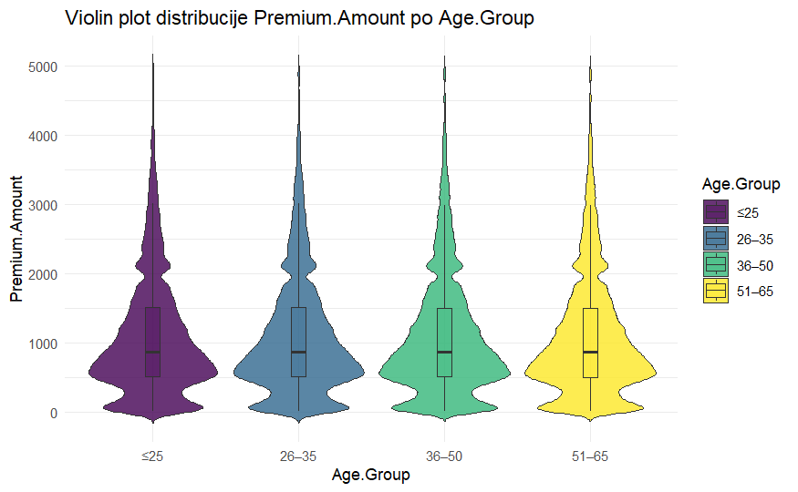

```r
ggplot(data, aes(x = Age.Group, y = Premium.Amount, fill = Age.Group)) +
  geom_violin(trim = FALSE, alpha = 0.8) +
  geom_boxplot(width = 0.1, outlier.shape = NA, alpha = 0.3) +
  labs(title = "Violin plot distribucije Premium.Amount po Age.Group", x = "Age.Group", y = "Premium.Amount") +
  theme_minimal()
```

Statisticka analiza zavisnosti varijabli

```r
set.seed(123)
categories <- unique(data$Age.Group)
categories <- categories[!is.na(categories)]

shapiro_boot <- function(cat) {
  values <- na.omit(data$Premium.Amount[data$Age.Group == cat])

  if (length(values) > 3) {
    p_values <- replicate(500, shapiro.test(sample(values, min(3000, length(values))))$p.value)
    p_mean <- mean(p_values)

    if (p_mean > 0.05) {
      sprintf("Varijabla Premium.Amount po %s kategoriji ima normalnu raspodelu.", as.character(cat))
    } else {
      sprintf("Varijabla Premium.Amount po %s kategoriji nema normalnu raspodelu.", as.character(cat))
    }
  }
  else {
    sprintf("Varijabla Premium.Amount po %s kategoriji ima manje od 3 observacije.", as.character(cat))
  }
}

lapply(categories, shapiro_boot)
```

```
[[1]]
[1] "Varijabla Premium.Amount po ≤25 kategoriji nema normalnu raspodelu."

[[2]]
[1] "Varijabla Premium.Amount po 36–50 kategoriji nema normalnu raspodelu."

[[3]]
[1] "Varijabla Premium.Amount po 26–35 kategoriji nema normalnu raspodelu."

[[4]]
[1] "Varijabla Premium.Amount po 51–65 kategoriji nema normalnu raspodelu."
```

Kruskal-Wallis test radi statisticke provere distribucije po kategorijama

```r
p_value <- kruskal_test(Premium.Amount ~ Age.Group, data = data)$p

if (p_value > 0.05) {
  print("Nema statisticke razlike izmedju distribucija Premium.Amount po kategorijama Age.Group atributa.")
} else {
  print("Postoji statisticka razlika izmedju distribucija Premium.Amount po kategorijama Age.Group atributa.")
}
```

```
[1] "Postoji statisticka razlika izmedju distribucija Premium.Amount po kategorijama Age.Group atributa."
```

Racunamo efekat Kruskal-Wallis testa kako bismo proverili:

```r
kruskal_effsize(Premium.Amount ~ Age.Group, data = data)$effsize
```

```
Kruskal-Wallis chi-squared
              5.110353e-06
```

## Income.Dependents

```r
data$Number.of.Dependents.Num <- as.character(data$Number.of.Dependents)
data$Number.of.Dependents.Num <- as.numeric(data$Number.of.Dependents.Num)

data$Income.Dependents <- ifelse(
  is.na(data$Number.of.Dependents.Num),
  NA,
  data$Annual.Income / (data$Number.of.Dependents.Num + 1)
)

data <- data %>%
  select(-Number.of.Dependents.Num)
```

```r
summary(data$Income.Dependents)
```

```
    Min.  1st Qu.   Median     Mean  3rd Qu.     Max.
     0.4   3023.8   7922.3  14142.8  17730.0 149997.0
```

Graficki prikaz podataka

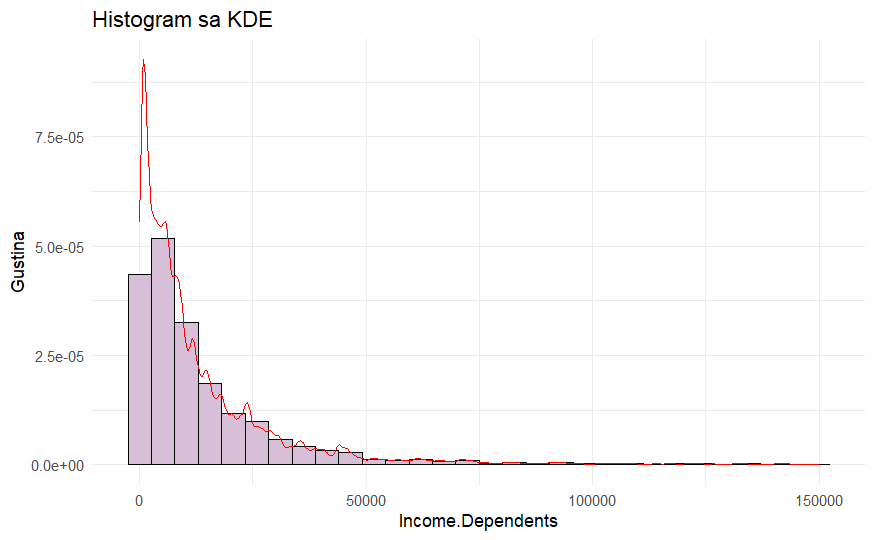

```r
ggplot(data, aes(x = Income.Dependents)) +
  geom_histogram(aes(y = ..density..), bins = 30, fill = "thistle", color = "black") +
  geom_density(color = "red") +
  theme_minimal() +
  labs(title = "Histogram sa KDE", x = "Income.Dependents", y = "Gustina")
```

```r
data$Income.Dependents <- log(data$Income.Dependents)
```

Graficki prikaz podataka

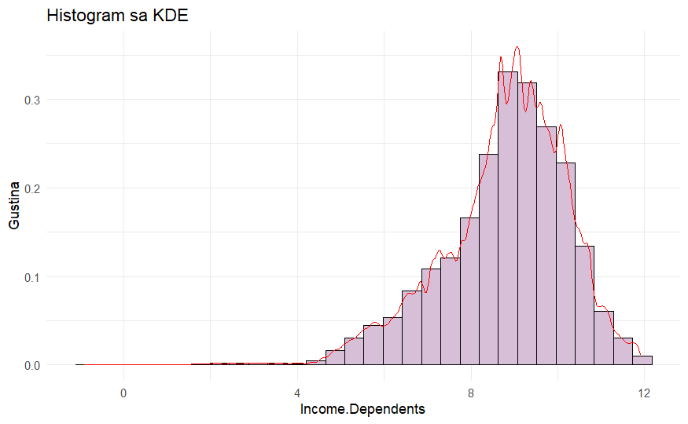

```r
ggplot(data, aes(x = Income.Dependents)) +
  geom_histogram(aes(y = ..density..), bins = 30, fill = "thistle", color = "black") +
  geom_density(color = "red") +
  theme_minimal() +
  labs(title = "Histogram sa KDE", x = "Income.Dependents", y = "Gustina")
```

#### Income.Dependents vs. Premium.Amount

Graficka reprezentacija varijabli

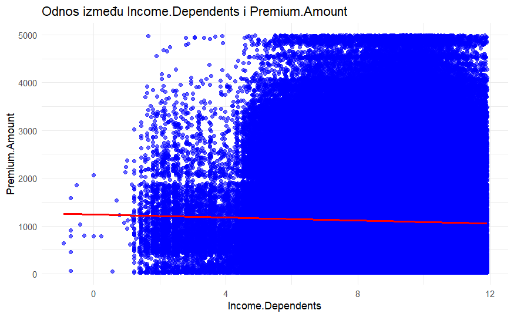

```r
ggplot(data, aes(x = Income.Dependents, y = Premium.Amount)) +
  geom_point(alpha = 0.6, color = "blue") +
  geom_smooth(method = "lm", se = TRUE, color = "red") +
  labs(title = "Odnos između Income.Dependents i Premium.Amount", x = "Income.Dependents", y = "Premium.Amount") +
  theme_minimal()
```

Statisticka analiza zavisnosti varijabli

```r
cor.test(data$Premium.Amount, data$Income.Dependents, method = "spearman")
```

```
    Spearman's rank correlation rho

data:  data$Premium.Amount and data$Income.Dependents
S = 3.0351e+17, p-value < 2.2e-16
alternative hypothesis: true rho is not equal to 0
sample estimates:
        rho
-0.05384118
```

Spearmanova korelacija izmedju Premium.Amount i Income.Dependents je statisticki znacajna (ρ = −0.054, p < 0.05), ali izuzetno slaba. S obzirom na veoma veliki uzorak, statisticka znacajnost ne implicira prakticnu vaznost, te se zakljucuje da Income.Dependents nema relevantan uticaj na Premium.Amount.

## Income.Credit

Pomocu atributa Annual.Income i Credit.Score kreiramo novu promenljivu Income.Credit koja predstavlja indikator finansijske stabilnosti

```r
data$Income.Credit <- data$Annual.Income * data$Credit.Score
```

Graficki prikaz podataka

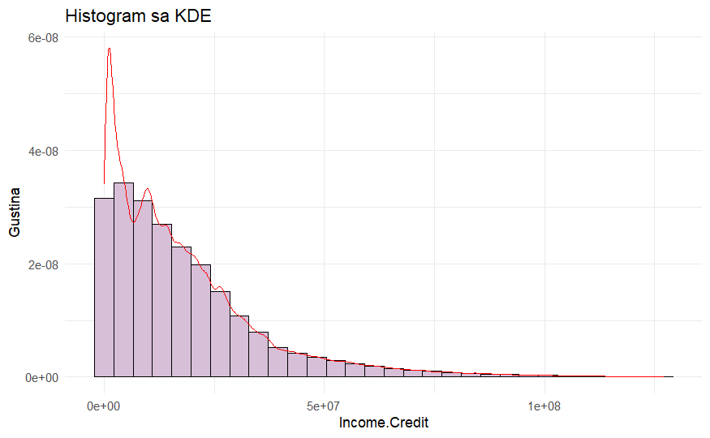

```r
ggplot(data, aes(x = Income.Credit)) +
  geom_histogram(aes(y = ..density..), bins = 30, fill = "thistle", color = "black") +
  geom_density(color = "red") +
  theme_minimal() +
  labs(title = "Histogram sa KDE", x = "Income.Credit", y = "Gustina")
```

Logaritamska transformacija

```r
data$Income.Credit <- log(data$Income.Credit)
```

Graficki prikaz podataka

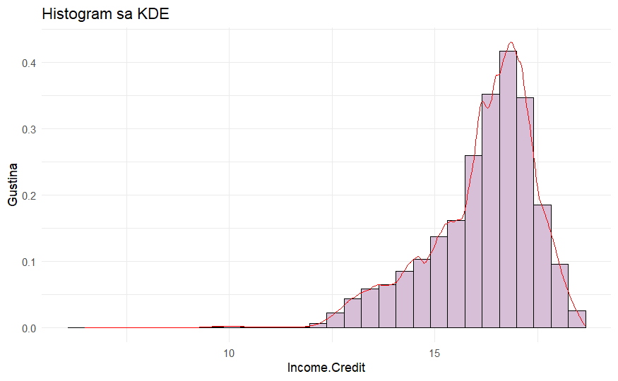

```r
ggplot(data, aes(x = Income.Credit)) +
  geom_histogram(aes(y = ..density..), bins = 30, fill = "thistle", color = "black") +
  geom_density(color = "red") +
  theme_minimal() +
  labs(title = "Histogram sa KDE", x = "Income.Credit", y = "Gustina")
```

#### Income.Credit vs. Premium.Amount

Graficka reprezentacija varijabli

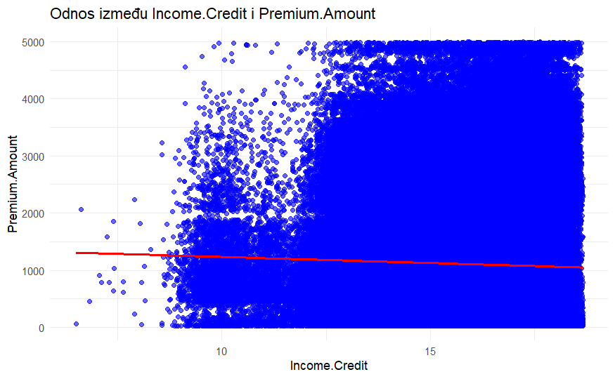

```r
ggplot(data, aes(x = Income.Credit, y = Premium.Amount)) +
  geom_point(alpha = 0.6, color = "blue") +
  geom_smooth(method = "lm", se = TRUE, color = "red") +
  labs(title = "Odnos između Income.Credit i Premium.Amount", x = "Income.Credit", y = "Premium.Amount") +
  theme_minimal()
```

Statisticka analiza zavisnosti varijabli

```r
cor.test(data$Premium.Amount, data$Income.Credit, method = "spearman")
```

```
    Spearman's rank correlation rho

data:  data$Premium.Amount and data$Income.Credit
S = 3.085e+17, p-value < 2.2e-16
alternative hypothesis: true rho is not equal to 0
sample estimates:
        rho
-0.07117307
```

Spearmanova korelacija izmedju Premium.Amount i Income.Credit je statisticki znacajna (ρ = −0.071, p < 0.05), ali vrlo slaba. S obzirom na izuzetno veliki uzorak, statisticka znacajnost ne implicira prakticnu relevantnost, te se zakljucuje da Income.Credit ima ogranicen samostalni uticaj na iznos premije.

## Log transformacija Annual.Income i Income.Group

Graficki prikaz podataka

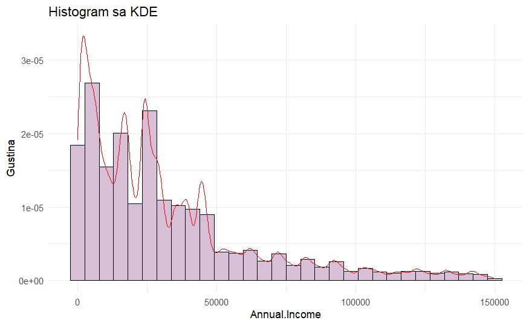

```r
ggplot(data, aes(x = Annual.Income)) +
  geom_histogram(aes(y = ..density..), bins = 30, fill = "thistle", color = "black") +
  geom_density(color = "red") +
  theme_minimal() +
  labs(title = "Histogram sa KDE", x = "Annual.Income", y = "Gustina")
```

Logaritamska transformacija

```r
data$Annual.Income <- log(data$Annual.Income)
```

Graficki prikaz podataka

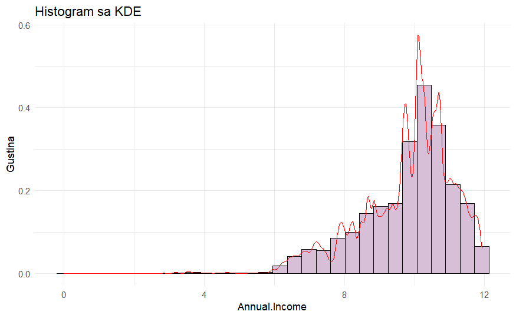

```r
ggplot(data, aes(x = Annual.Income)) +
  geom_histogram(aes(y = ..density..), bins = 30, fill = "thistle", color = "black") +
  geom_density(color = "red") +
  theme_minimal() +
  labs(title = "Histogram sa KDE", x = "Annual.Income", y = "Gustina")
```

Od atributa Annual.Income kreiramo novi atribut Income.Group

```r
sum(is.na(data$Annual.Income))
```

```
[1] 0
```

```r
q <- quantile(data$Annual.Income, probs = c(0, 0.25, 0.5, 0.75, 1))

data$Income.Group <- cut(
  data$Annual.Income,
  breaks = q,
  include.lowest = TRUE,
  labels = c("Low", "Mid-Low", "Mid-High", "High"),
  ordered_result = TRUE
)
```

Graficki prikaz podataka

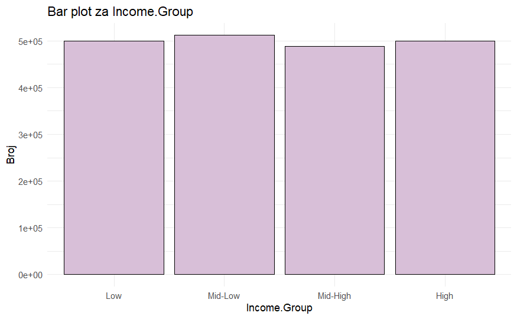

```r
ggplot(data, aes(x = Income.Group)) +
  geom_bar(fill = "thistle", color = "black") +
  labs(title = "Bar plot za Income.Group", x = "Income.Group", y = "Broj") +
  theme_minimal()
```

```r
table(data$Income.Group)
```

```
     Low  Mid-Low Mid-High     High
  500007   512224   487871   499898
```

#### Income.Group vs. Premium.Amount

Osnovni opis varijabli

```r
df_summary_feature <- data %>%
  group_by(Income.Group) %>%
  summarise(
    Count = n(),
    Mean_Premium_Amount = mean(Premium.Amount, na.rm = TRUE),
    Median_Premium_Amount = median(Premium.Amount, na.rm = TRUE),
    Std_Premium_Amount = sd(Premium.Amount, na.rm = TRUE),
    IQR_Premium_Amount = IQR(Premium.Amount, na.rm = TRUE)
  )

print(df_summary_feature)
```

| Income.Group | Count | Mean_Premium_Amount | Median_Premium_Amount | Std_Premium_Amount | IQR_Premium_Amount |
| --- | --- | --- | --- | --- | --- |
| Low | 500007 | 1162.730 | 919 | 881.1312 | 1058 |
| Mid-Low | 512224 | 1065.608 | 874 | 778.3298 | 857 |
| Mid-High | 487871 | 1091.683 | 896 | 778.7001 | 859 |
| High | 499898 | 1090.799 | 772 | 999.7255 | 1370 |

Graficka reprezentacija varijabli

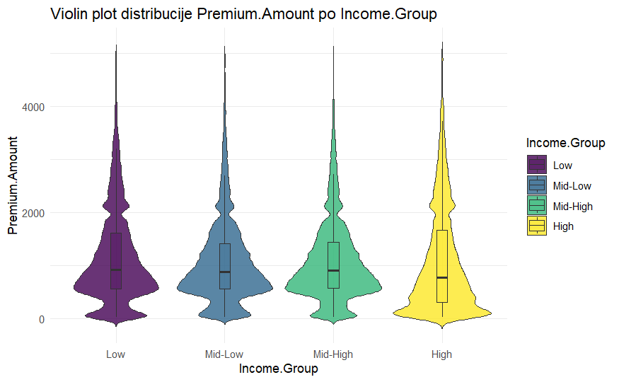

```r
ggplot(data, aes(x = Income.Group, y = Premium.Amount, fill = Income.Group)) +
  geom_violin(trim = FALSE, alpha = 0.8) +
  geom_boxplot(width = 0.1, outlier.shape = NA, alpha = 0.3) +
  labs(title = "Violin plot distribucije Premium.Amount po Income.Group", x = "Income.Group", y = "Premium.Amount") +
  theme_minimal()
```

Statisticka analiza zavisnosti varijabli

```r
set.seed(123)
categories <- unique(data$Income.Group)
categories <- categories[!is.na(categories)]

shapiro_boot <- function(cat) {
  values <- na.omit(data$Premium.Amount[data$Income.Group == cat])

  if (length(values) > 3) {
    p_values <- replicate(500, shapiro.test(sample(values, min(3000, length(values))))$p.value)
    p_mean <- mean(p_values)

    if (p_mean > 0.05) {
      sprintf("Varijabla Premium.Amount po %s kategoriji ima normalnu raspodelu.", as.character(cat))
    } else {
      sprintf("Varijabla Premium.Amount po %s kategoriji nema normalnu raspodelu.", as.character(cat))
    }
  }
  else {
    sprintf("Varijabla Premium.Amount po %s kategoriji ima manje od 3 observacije.", as.character(cat))
  }
}

lapply(categories, shapiro_boot)
```

```
[[1]]
[1] "Varijabla Premium.Amount po Mid-Low kategoriji nema normalnu raspodelu."

[[2]]
[1] "Varijabla Premium.Amount po Mid-High kategoriji nema normalnu raspodelu."

[[3]]
[1] "Varijabla Premium.Amount po High kategoriji nema normalnu raspodelu."

[[4]]
[1] "Varijabla Premium.Amount po Low kategoriji nema normalnu raspodelu."
```

Kruskal-Wallis test radi statisticke provere distribucije po kategorijama

```r
p_value <- kruskal_test(Premium.Amount ~ Income.Group, data = data)$p

if (p_value > 0.05) {
  print("Nema statisticke razlike izmedju distribucija Premium.Amount po kategorijama Income.Group atributa.")
} else {
  print("Postoji statisticka razlika izmedju distribucija Premium.Amount po kategorijama Income.Group atributa.")
}
```

```
[1] "Postoji statisticka razlika izmedju distribucija Premium.Amount po kategorijama Income.Group atributa."
```

```r
kruskal_effsize(Premium.Amount ~ Income.Group, data = data)$effsize
```

```
Kruskal-Wallis chi-squared
               0.003016009
```

## Health.Group

Graficki prikaz podataka

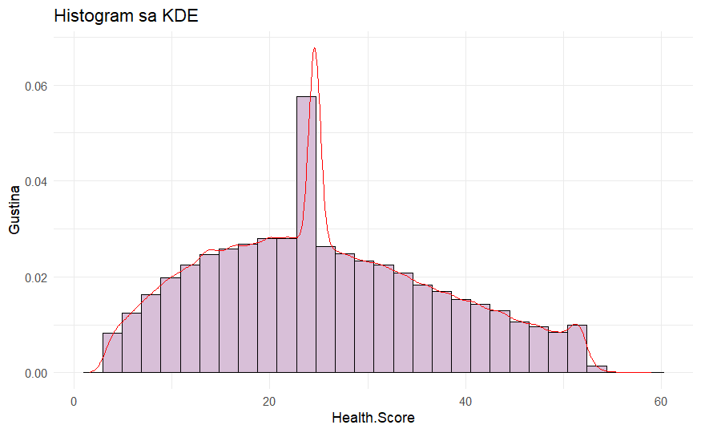

```r
ggplot(data, aes(x = Health.Score)) +
  geom_histogram(aes(y = ..density..), bins = 30, fill = "thistle", color = "black") +
  geom_density(color = "red") +
  theme_minimal() +
  labs(title = "Histogram sa KDE", x = "Health.Score", y = "Gustina")
```

Od atributa Health.Score kreiramo novi atribut Health.Group

```r
q <- quantile(data$Health.Score, probs = c(0, 1/3, 2/3, 1))

data$Health.Group <- cut(
  data$Health.Score,
  breaks = q,
  include.lowest = TRUE,
  labels = c("Low", "Medium", "High"),
  ordered_result = TRUE
)
```

Graficki prikaz podataka

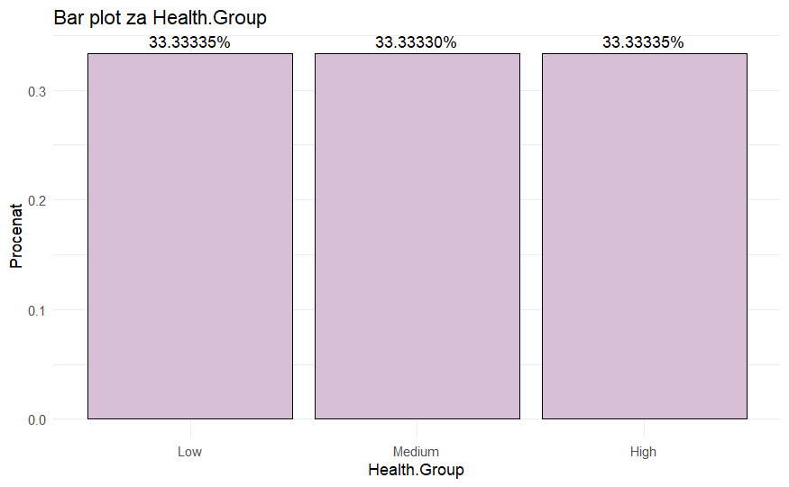

```r
ggplot(data, aes(x = Health.Group, y = ..prop.., group = 1)) +
  geom_bar(fill = "thistle", color = "black") +
  geom_text(aes(label = scales::percent(..prop..)), stat = "count", vjust = -0.5) +
  labs(title = "Bar plot za Health.Group", x = "Health.Group", y = "Procenat") +
  theme_minimal()
```

#### Health.Group vs. Premium.Amount

Osnovni opis varijabli

```r
df_summary_feature <- data %>%
  group_by(Health.Group) %>%
  summarise(
    Count = n(),
    Mean_Premium_Amount = mean(Premium.Amount, na.rm = TRUE),
    Median_Premium_Amount = median(Premium.Amount, na.rm = TRUE),
    Std_Premium_Amount = sd(Premium.Amount, na.rm = TRUE),
    IQR_Premium_Amount = IQR(Premium.Amount, na.rm = TRUE)
  )

print(df_summary_feature)
```

| Health.Group | Count | Mean_Premium_Amount | Median_Premium_Amount | Std_Premium_Amount | IQR_Premium_Amount |
| --- | --- | --- | --- | --- | --- |
| Low | 666667 | 1094.683 | 860 | 871.1115 | 1016 |
| Medium | 666666 | 1093.287 | 864 | 848.6958 | 958 |
| High | 666667 | 1119.666 | 886 | 874.7166 | 1018 |

Graficka reprezentacija varijabli

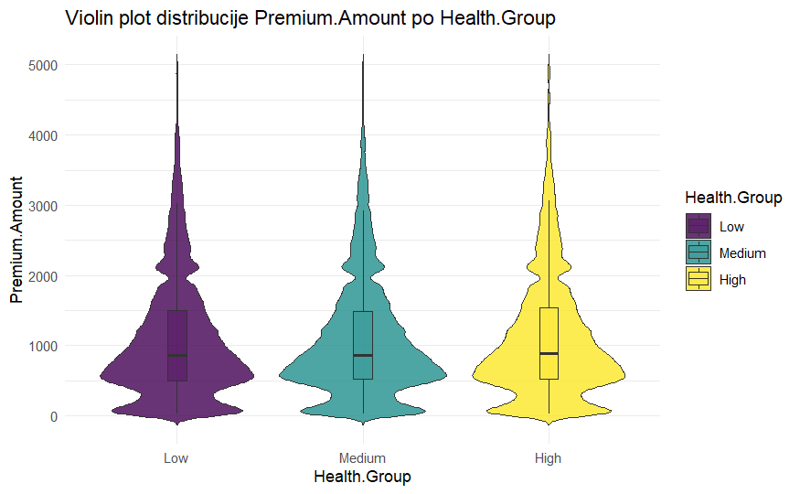

```r
ggplot(data, aes(x = Health.Group, y = Premium.Amount, fill = Health.Group)) +
  geom_violin(trim = FALSE, alpha = 0.8) +
  geom_boxplot(width = 0.1, outlier.shape = NA, alpha = 0.3) +
  labs(title = "Violin plot distribucije Premium.Amount po Health.Group", x = "Health.Group", y = "Premium.Amount") +
  theme_minimal()
```

Statisticka analiza zavisnosti varijabli

```r
set.seed(123)
categories <- unique(data$Health.Group)
categories <- categories[!is.na(categories)]

shapiro_boot <- function(cat) {
  values <- na.omit(data$Premium.Amount[data$Health.Group == cat])

  if (length(values) > 3) {
    p_values <- replicate(500, shapiro.test(sample(values, min(3000, length(values))))$p.value)
    p_mean <- mean(p_values)

    if (p_mean > 0.05) {
      sprintf("Varijabla Premium.Amount po %s kategoriji ima normalnu raspodelu.", as.character(cat))
    } else {
      sprintf("Varijabla Premium.Amount po %s kategoriji nema normalnu raspodelu.", as.character(cat))
    }
  }
  else {
    sprintf("Varijabla Premium.Amount po %s kategoriji ima manje od 3 observacije.", as.character(cat))
  }
}

lapply(categories, shapiro_boot)
```

```
[[1]]
[1] "Varijabla Premium.Amount po Medium kategoriji nema normalnu raspodelu."

[[2]]
[1] "Varijabla Premium.Amount po Low kategoriji nema normalnu raspodelu."

[[3]]
[1] "Varijabla Premium.Amount po High kategoriji nema normalnu raspodelu."
```

Kruskal-Wallis test radi statisticke provere distribucije po kategorijama

```r
p_value <- kruskal_test(Premium.Amount ~ Health.Group, data = data)$p

if (p_value > 0.05) {
  print("Nema statisticke razlike izmedju distribucija Premium.Amount po kategorijama Health.Group atributa.")
} else {
  print("Postoji statisticka razlika izmedju distribucija Premium.Amount po kategorijama Health.Group atributa.")
}
```

```
[1] "Postoji statisticka razlika izmedju distribucija Premium.Amount po kategorijama Health.Group atributa."
```

```r
kruskal_effsize(Premium.Amount ~ Health.Group, data = data)$effsize
```

```
Kruskal-Wallis chi-squared
              0.0001204868
```

Iako je Kruskal–Wallis test ukazao na to da postoji statistički značajna razlika u raspodeli varijable Premium.Amount u odnosu na nivoe varijable Health.Group, analizom vrednosti efekta, kao i poređenjem medijana i IQR-a, utvrđujemo da je ova razlika minimalna i praktično zanemarljiva.

## Previous.Claims spojiti za 7+

Posto su grupe koje imaju 7-9 zahteva veoma male, grupisacemo ih u jednu kategoriju “7+”

```r
data$Previous.Claims <- as.character(data$Previous.Claims)
data$Previous.Claims[data$Previous.Claims %in% c("7","8","9")] <- "7+"
data$Previous.Claims <- factor(data$Previous.Claims,
                                      levels = c("0","1","2","3","4","5","6","7+", "UNKNOWN"))

table(data$Previous.Claims, useNA="ifany")
```

```
      0       1       2       3       4       5       6      7+ UNKNOWN
 508239  501692  279761   81764   17689    3411     506     107  606831
```

## Policy.Year i Policy.Season

Od char atributa Policy.Start.Date kreiramo atribute Policy.Year i Policy.Season

```r
data$Policy.Start.Date <- ymd_hms(data$Policy.Start.Date)

data$Policy.Year  <- year(data$Policy.Start.Date)

data$Policy.Season <- cut(
  month(data$Policy.Start.Date),
  breaks = c(0, 2, 5, 8, 11, 12),
  labels = c("Winter", "Spring", "Summer", "Autumn", "Winter"),
  include.lowest = TRUE,
  right = TRUE
)

data <- data %>%
  select(-Policy.Start.Date)
```

Graficki prikaz podataka

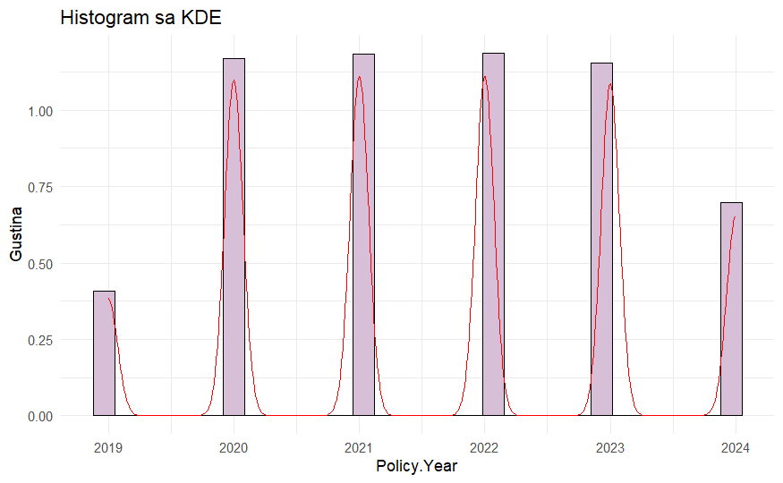

```r
ggplot(data, aes(x = Policy.Year)) +
  geom_histogram(aes(y = ..density..), bins = 30, fill = "thistle", color = "black") +
  geom_density(color = "red") +
  theme_minimal() +
  labs(title = "Histogram sa KDE", x = "Policy.Year", y = "Gustina")
```

Graficki prikaz podataka

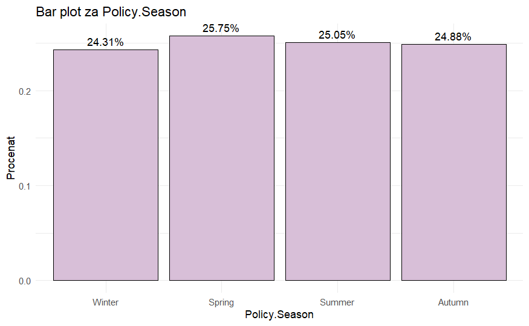

```r
ggplot(data, aes(x = Policy.Season, y = ..prop.., group = 1)) +
  geom_bar(fill = "thistle", color = "black") +
  geom_text(aes(label = scales::percent(..prop..)), stat = "count", vjust = -0.5) +
  labs(title = "Bar plot za Policy.Season", x = "Policy.Season", y = "Procenat") +
  theme_minimal()
```

#### Policy.Season vs. Premium.Amount

Osnovni opis varijabli

```r
df_summary_feature <- data %>%
  group_by(Policy.Season) %>%
  summarise(
    Count = n(),
    Mean_Premium_Amount = mean(Premium.Amount, na.rm = TRUE),
    Median_Premium_Amount = median(Premium.Amount, na.rm = TRUE),
    Std_Premium_Amount = sd(Premium.Amount, na.rm = TRUE),
    IQR_Premium.Amount = IQR(Premium.Amount, na.rm = TRUE)
  ) %>%
  arrange(desc(Mean_Premium_Amount))

print(df_summary_feature)
```

| Policy.Season | Count | Mean_Premium_Amount | Median_Premium_Amount | Std_Premium_Amount | IQR_Premium.Amount |
| --- | --- | --- | --- | --- | --- |
| Autumn | 497632 | 1113.387 | 882 | 872.0622 | 1010 |
| Winter | 486233 | 1102.454 | 870 | 866.3771 | 994 |
| Summer | 501064 | 1099.309 | 869 | 863.2141 | 986 |
| Spring | 515071 | 1095.296 | 867 | 858.4505 | 980 |

Graficka reprezentacija varijabli

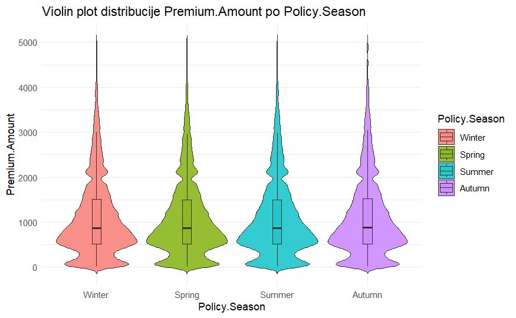

```r
ggplot(data, aes(x = Policy.Season, y = Premium.Amount, fill = Policy.Season)) +
  geom_violin(trim = FALSE, alpha = 0.8) +
  geom_boxplot(width = 0.1, outlier.shape = NA, alpha = 0.3) +
  labs(title = "Violin plot distribucije Premium.Amount po Policy.Season", x = "Policy.Season", y = "Premium.Amount") +
  theme_minimal()
```

Statisticka analiza zavisnosti varijabli

```r
set.seed(123)
categories <- unique(data$Policy.Season)
categories <- categories[!is.na(categories)]

shapiro_boot <- function(cat) {
  values <- na.omit(data$Premium.Amount[data$Policy.Season == cat])

  if (length(values) > 3) {
    p_values <- replicate(500, shapiro.test(sample(values, min(3000, length(values))))$p.value)
    p_mean <- mean(p_values)

    if (p_mean > 0.05) {
      sprintf("Varijabla Premium.Amount po %s kategoriji ima normalnu raspodelu.", as.character(cat))
    } else {
      sprintf("Varijabla Premium.Amount po %s kategoriji nema normalnu raspodelu.", as.character(cat))
    }
  }
  else {
    sprintf("Varijabla Premium.Amount po %s kategoriji ima manje od 3 observacije.", as.character(cat))
  }
}

lapply(categories, shapiro_boot)
```

```
[[1]]
[1] "Varijabla Premium.Amount po Winter kategoriji nema normalnu raspodelu."

[[2]]
[1] "Varijabla Premium.Amount po Summer kategoriji nema normalnu raspodelu."

[[3]]
[1] "Varijabla Premium.Amount po Autumn kategoriji nema normalnu raspodelu."

[[4]]
[1] "Varijabla Premium.Amount po Spring kategoriji nema normalnu raspodelu."
```

Kruskal-Wallis test radi statisticke provere distribucije po kategorijama

```r
p_value <- kruskal_test(Premium.Amount ~ Policy.Season, data = data)$p

if (p_value > 0.05) {
  print("Nema statisticke razlike izmedju distribucija Premium.Amount po kategorijama Policy.Season atributa.")
} else {
  print("Postoji statisticka razlika izmedju distribucija Premium.Amount po kategorijama Policy.Season atributa.")
}
```

```
[1] "Postoji statisticka razlika izmedju distribucija Premium.Amount po kategorijama Policy.Season atributa."
```

```r
kruskal_effsize(Premium.Amount ~ Policy.Season, data = data)$effsize
```

```
Kruskal-Wallis chi-squared
              2.500618e-05
```

Iako je Kruskal–Wallis test ukazao na to da postoji statistički značajna razlika u raspodeli varijable Premium.Amount u odnosu na nivoe varijable Policy.Season, analizom vrednosti efekta, kao i poređenjem medijana i IQR-a, utvrđujemo da je ova razlika minimalna i praktično zanemarljiva.

#### Policy.Year vs. Premium.Amount

Graficka reprezentacija varijabli

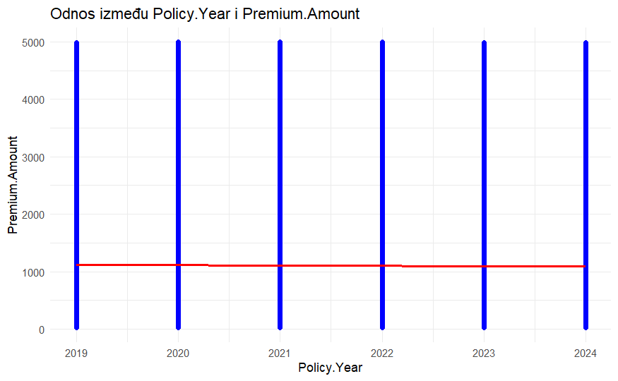

```r
ggplot(data, aes(x = Policy.Year, y = Premium.Amount)) +
  geom_point(alpha = 0.6, color = "blue") +
  geom_smooth(method = "lm", se = TRUE, color = "red") +
  labs(title = "Odnos između Policy.Year i Premium.Amount", x = "Policy.Year", y = "Premium.Amount") +
  theme_minimal()
```

Statisticka analiza zavisnosti varijabli

```r
cor.test(data$Premium.Amount, data$Policy.Year, method = "spearman")
```

```
    Spearman's rank correlation rho

data:  data$Premium.Amount and data$Policy.Year
S = 2.9095e+17, p-value < 2.2e-16
alternative hypothesis: true rho is not equal to 0
sample estimates:
       rho
-0.0102577
```

Spearmanova korelacija izmedju godine ugovaranja polise i iznosa premije je statisticki znacajna (ρ = −0.01, p < 0.05), ali zanemarljive jacine. Rezultat ukazuje da promena godine ugovaranja nema prakticno relevantan uticaj na visinu premije.

## Health.Claims

```r
data <- data %>%
  group_by(Previous.Claims) %>%
  mutate(
    Health.Claims = Health.Score / mean(Health.Score)
  ) %>%
  ungroup()
```

Graficki prikaz podataka

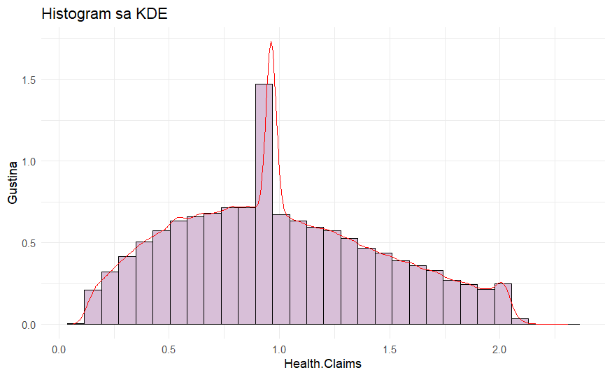

```r
ggplot(data, aes(x = Health.Claims)) +
  geom_histogram(aes(y = ..density..), bins = 30, fill = "thistle", color = "black") +
  geom_density(color = "red") +
  theme_minimal() +
  labs(title = "Histogram sa KDE", x = "Health.Claims", y = "Gustina")
```

#### Health.Claims vs. Premium.Amount

Graficka reprezentacija varijabli

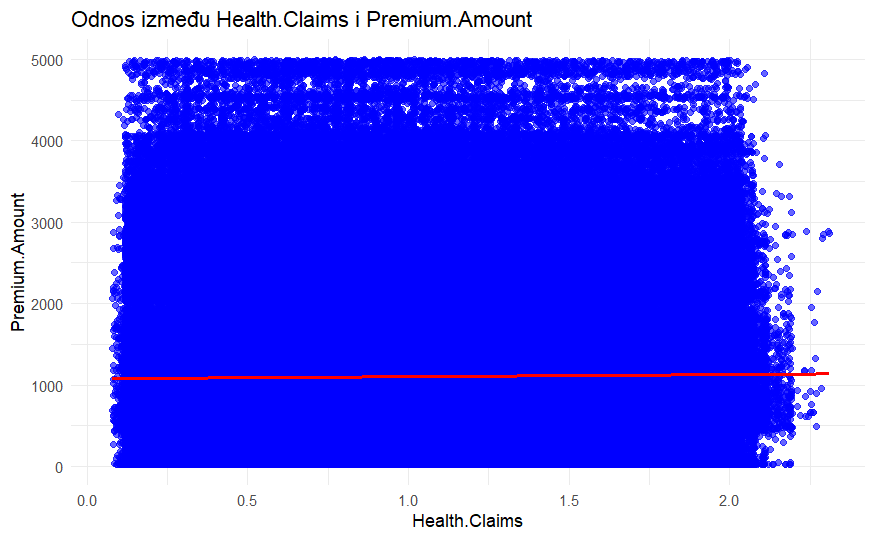

```r
ggplot(data, aes(x = Health.Claims, y = Premium.Amount)) +
  geom_point(alpha = 0.6, color = "blue") +
  geom_smooth(method = "lm", se = TRUE, color = "red") +
  labs(title = "Odnos između Health.Claims i Premium.Amount", x = "Health.Claims", y = "Premium.Amount") +
  theme_minimal()
```

Statisticka analiza zavisnosti varijabli

```r
cor.test(data$Premium.Amount, data$Health.Claims, method = "spearman")
```

```
    Spearman's rank correlation rho

data:  data$Premium.Amount and data$Health.Claims
S = 2.8363e+17, p-value < 2.2e-16
alternative hypothesis: true rho is not equal to 0
sample estimates:
       rho
0.01517275
```

Spearmanova korelacija izmedju Health.Claims i Premium.Amount je statisticki znacajna (ρ = 0.01517, p < 0.05), ali zanemarljive jacine. Rezultat ukazuje da kombinacija ocene zdravlja i broja prethodnih zahteva nema prakticno relevantan uticaj na visinu premije.

## Health.Age

Na osnovu Health.Score i Age atributa kreiramo novi, Health.Age, koji ukazuje na zdravlje klijenta u skladu sa godinama.

```r
data$Health.Age <- data$Health.Score * data$Age
```

Graficki prikaz podataka

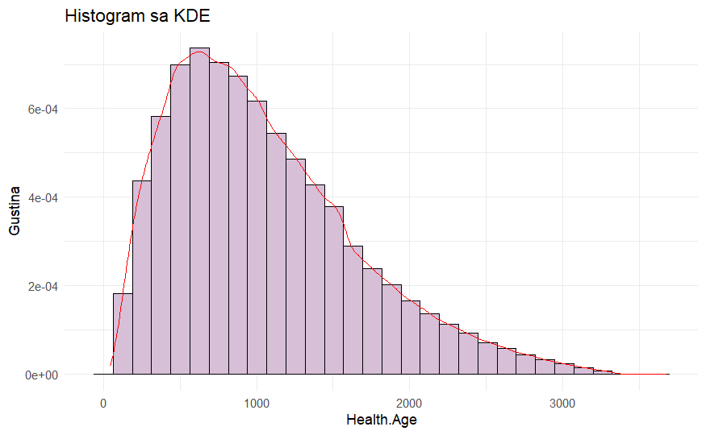

```r
ggplot(data, aes(x = Health.Age)) +
  geom_histogram(aes(y = ..density..), bins = 30, fill = "thistle", color = "black") +
  geom_density(color = "red") +
  theme_minimal() +
  labs(title = "Histogram sa KDE", x = "Health.Age", y = "Gustina")
```

Logaritamska transformacija

```r
data$Health.Age <- log(data$Health.Age)
```

Graficki prikaz podataka

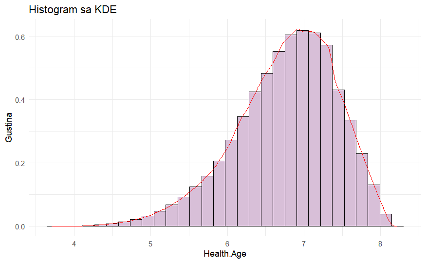

```r
ggplot(data, aes(x = Health.Age)) +
  geom_histogram(aes(y = ..density..), bins = 30, fill = "thistle", color = "black") +
  geom_density(color = "red") +
  theme_minimal() +
  labs(title = "Histogram sa KDE", x = "Health.Age", y = "Gustina")
```

#### Health.Age vs. Premium.Amount

Graficka reprezentacija varijabli

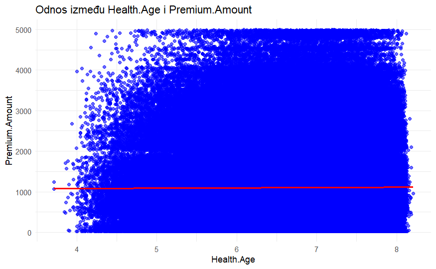

```r
ggplot(data, aes(x = Health.Age, y = Premium.Amount)) +
  geom_point(alpha = 0.6, color = "blue") +
  geom_smooth(method = "lm", se = TRUE, color = "red") +
  labs(title = "Odnos između Health.Age i Premium.Amount", x = "Health.Age", y = "Premium.Amount") +
  theme_minimal()
```

Statisticka analiza zavisnosti varijabli

```r
cor.test(data$Premium.Amount, data$Health.Age, method = "spearman")
```

```
    Spearman's rank correlation rho

data:  data$Premium.Amount and data$Health.Age
S = 2.8501e+17, p-value < 2.2e-16
alternative hypothesis: true rho is not equal to 0
sample estimates:
       rho
0.01038053
```

## Log transformacija Premium.Amount

Graficki prikaz podataka

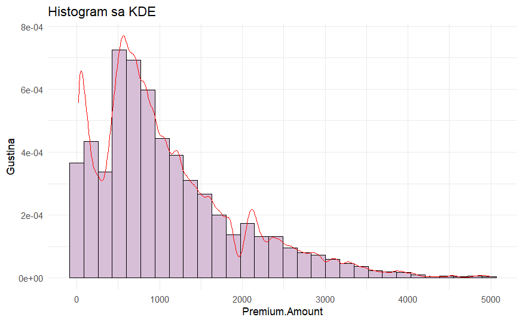

```r
ggplot(data, aes(x = Premium.Amount)) +
  geom_histogram(aes(y = ..density..), bins = 30, fill = "thistle", color = "black") +
  geom_density(color = "red") +
  theme_minimal() +
  labs(title = "Histogram sa KDE", x = "Premium.Amount", y = "Gustina")
```

Logaritamska transformacija

```r
data$Premium.Amount <- log(data$Premium.Amount)
```

Graficki prikaz podataka

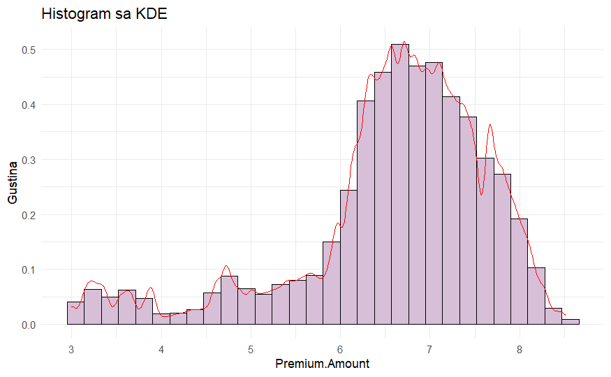

```r
ggplot(data, aes(x = Premium.Amount)) +
  geom_histogram(aes(y = ..density..), bins = 30, fill = "thistle", color = "black") +
  geom_density(color = "red") +
  theme_minimal() +
  labs(title = "Histogram sa KDE", x = "Premium.Amount", y = "Gustina")
```

## Korelaciona analiza numerickih varijabli

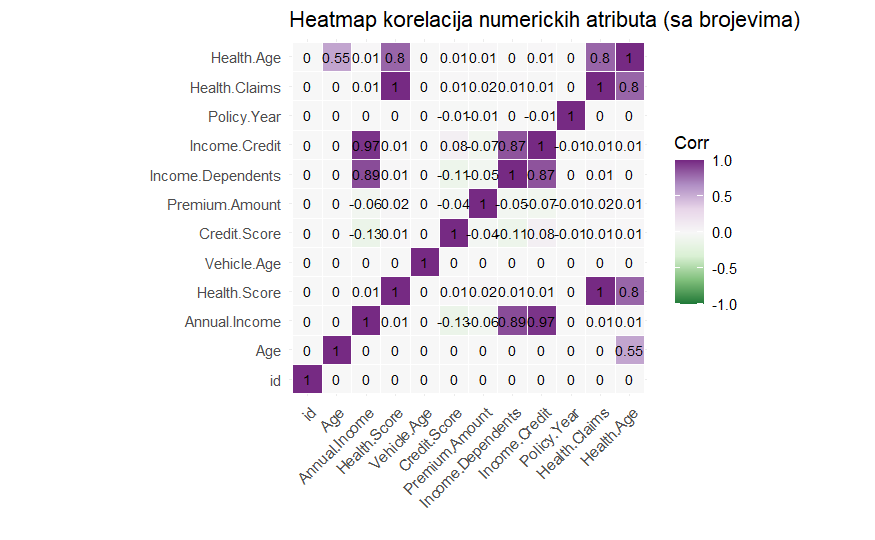

```r
num.data <- data[sapply(data, is.numeric)]
corr <- cor(num.data, use = "complete.obs", method = "spearman")

corr.melt <- melt(corr)

ggplot(corr.melt, aes(x = Var1, y = Var2, fill = value)) +
  geom_tile(color = "white") +
  geom_text(aes(label = round(value, 2)), size = 3) +
  scale_fill_distiller(palette = "PRGn", type = "div", limits = c(-1, 1)) +
  theme_minimal() +
  theme(axis.text.x = element_text(angle = 45, hjust = 1)) +
  coord_fixed() +
  labs(title = "Heatmap korelacija numerickih atributa (sa brojevima)", x = "", y = "", fill = "Corr")
```

Heat mape potvrdjuju da, iako je vecina osnovnih osobina slabo medjusobno povezana, izvedene osobine poput Age_Health i Income_Credit pokazuju snažnu unutrašnju vezu. Ne postoji jaka multikolinearnost između nepovezanih osobina, što znaci da je skup podataka pogodan za primenu i linearnih i nelinearnih modela.

# Enkodiranje

```r
list.feature.cat.ordinal <- c("Number.of.Dependents", "Education.Level", "Insurance.Duration", "Exercise.Frequency", "Age.Group", "Income.Group", "Health.Group")

list.feature.cat.onehot <- c("Gender", "Marital.Status", "Occupation", "Location", "Policy.Type", "Customer.Feedback", "Property.Type", "Policy.Season", "Smoking.Status", "Previous.Claims")

rec <- recipe(Premium.Amount ~ ., data = data) %>%
  step_ordinalscore(all_of(list.feature.cat.ordinal)) %>%
  step_dummy(all_of(list.feature.cat.onehot))

rec.prep <- prep(rec, training = data)
data.encoded <- bake(rec.prep, new_data = data)

str(data.encoded)
```

```
tibble [2,000,000 × 45] (S3: tbl_df/tbl/data.frame)
 $ id                       : int [1:2000000] 0 1 2 3 4 5 6 7 8 9 ...
 $ Age                      : num [1:2000000] 19 39 23 21 21 29 41 48 21 44 ...
 $ Annual.Income            : num [1:2000000] 9.22 10.36 10.15 11.86 10.59 ...
 $ Number.of.Dependents     : int [1:2000000] 2 4 4 3 2 2 1 3 4 3 ...
 $ Education.Level          : int [1:2000000] 2 3 1 2 2 2 4 1 2 3 ...
 $ Health.Score             : num [1:2000000] 22.6 15.6 47.2 10.9 20.4 ...
 $ Vehicle.Age              : num [1:2000000] 17 12 14 0 8 4 8 11 10 9 ...
 $ Credit.Score             : num [1:2000000] 372 694 595 367 598 614 807 398 685 635 ...
 $ Insurance.Duration       : int [1:2000000] 5 2 3 1 4 5 6 5 8 3 ...
 $ Exercise.Frequency       : int [1:2000000] 3 2 3 4 3 3 3 1 2 4 ...
 $ Age.Group                : int [1:2000000] 1 3 1 1 1 2 3 3 1 3 ...
 $ Income.Dependents        : num [1:2000000] 8.52 8.98 8.76 10.76 9.89 ...
 $ Income.Credit            : num [1:2000000] 15.1 16.9 16.5 17.8 17 ...
 $ Income.Group             : int [1:2000000] 2 3 3 4 3 4 3 4 1 4 ...
```

[output cut: 31 more lines]

# Podela na train i test skup

```r
train.preproc <- data.scaled[!is.na(data.scaled$Premium.Amount), ]

test.preproc <- data.scaled[is.na(data.scaled$Premium.Amount), ]
```

# Cuvanje train i test skupa

```r
write.csv(train.preproc, "train.preproc.csv", row.names = FALSE)
write.csv(test.preproc, "test.preproc.csv", row.names = FALSE)
```